# Modeling bivariate trend: Part 2

## Getting started

```r
# Load packages & import data
library(ggplot2)
library(dplyr)
bikes <- read.csv("https://www.macalester.edu/~dshuman1/data/155/bike_share.csv")
```

**Directions**

Same as usual! One new thing you’ll see are R chunks labeled `HINT CODE`. These are here to provide some code hints. Don’t type in or change these in any way.

**Goals**

Explore how to visualize, model, and interpret **bivariate** relationships between a quantitative response variable y and **categorical predictor** x.

## Exercises

### Exercise 1: Hello!

Who are you, how are you, and who will share their screen?

### Exercise 2: Step 1: Visualizations

As in the video, we’ll start by visualizing our relationship of interest, that between `riders_registered` and `weekend`. Separately run each chunk below, with two plots. Comment (`#`) on what changes in the code / output.

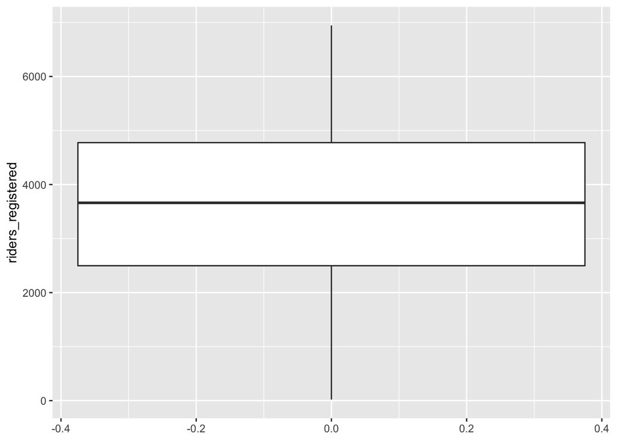

```r
# Univariate boxplot
ggplot(bikes, aes(y = riders_registered)) +
  geom_boxplot()
```

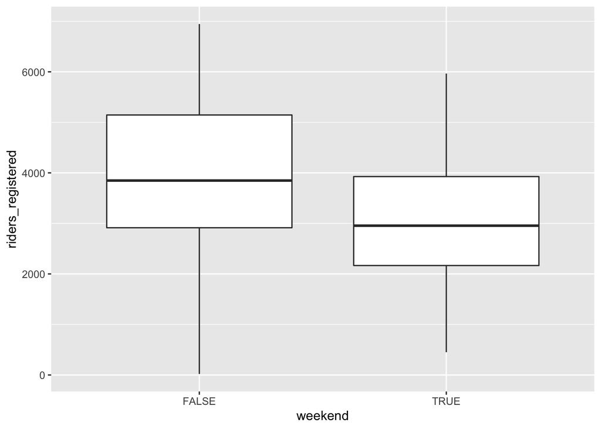

```r
# bivariate boxplot
ggplot(bikes, aes(y = riders_registered, x = weekend)) +
  geom_boxplot()
```

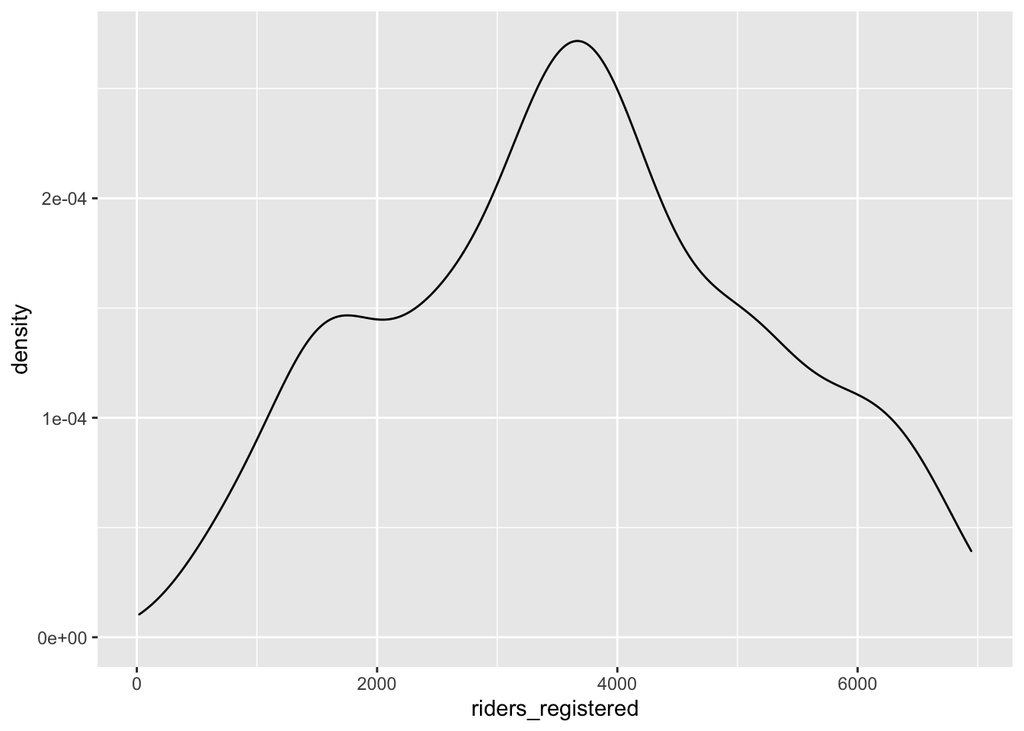

```r
# Univariate density plot
ggplot(bikes, aes(x = riders_registered)) +
  geom_density()
```

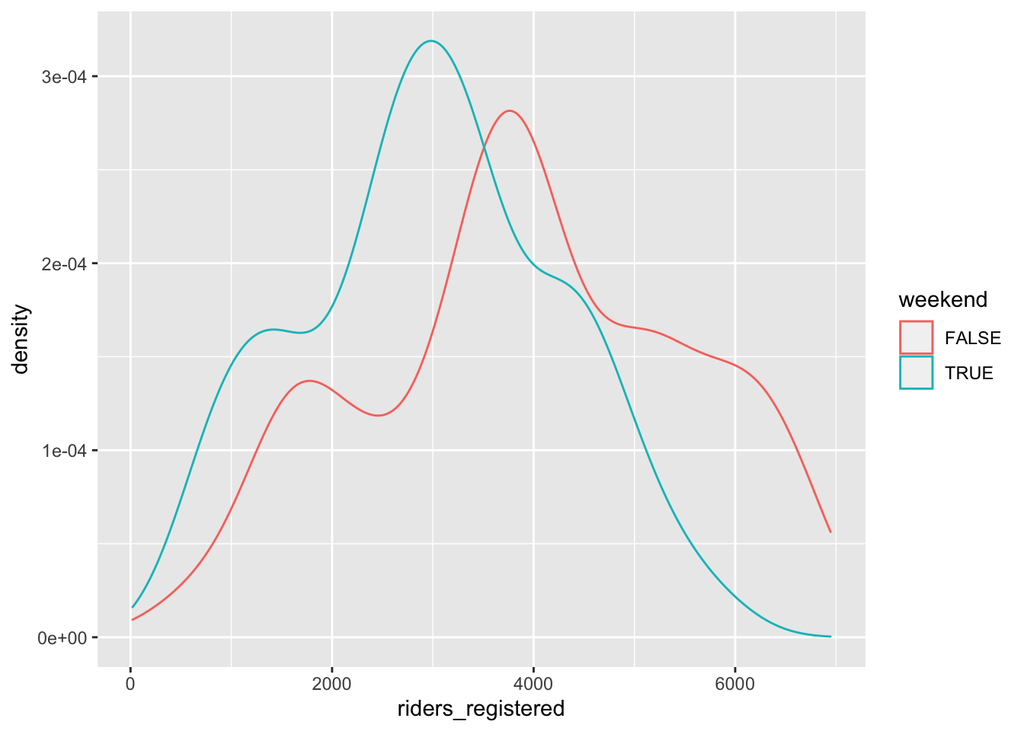

```r
# More even distribution when not weekends, but tends to be higher than on weekends
ggplot(bikes, aes(x = riders_registered, color = weekend)) +
  geom_density()
```

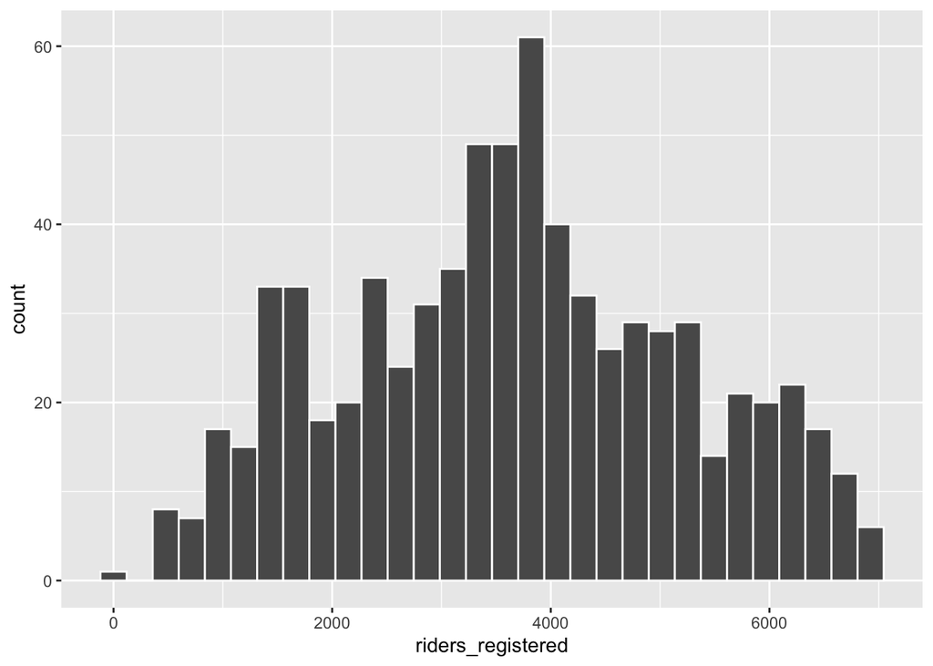

```r
# Univariate histogram
ggplot(bikes, aes(x = riders_registered)) +
  geom_histogram(color = "white")
```

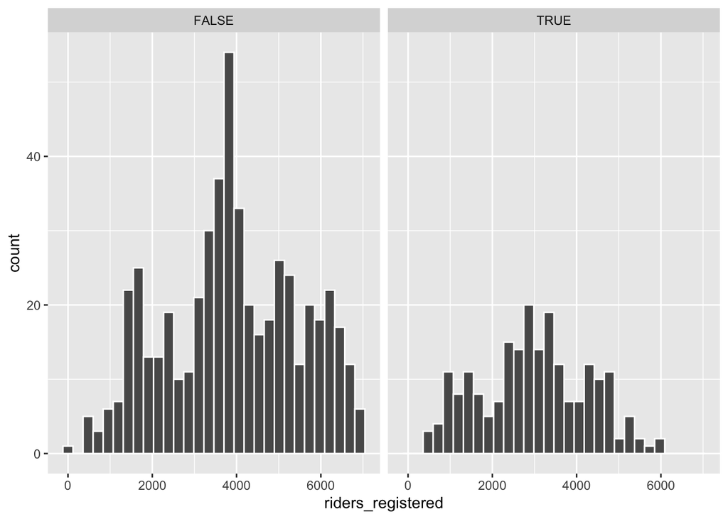

```r
# obviously more data points for the weekdays
ggplot(bikes, aes(x = riders_registered, color = weekend)) +
  geom_histogram(color = "white") +
  facet_wrap(~ weekend)
```

### Exercise 3: Numerical summaries of univariate trend

Let’s follow up the viz with some numerical summaries. Calculate the mean `riders_registered` value across all days.

```r
# HINT CODE: don't change this
bikes %>%
  ___(mean(___))
```

```r
# Your solution
bikes %>%
  summarize(mean(riders_registered))
```

```
##   mean(riders_registered)
## 1                3656.172
```

### Exercise 4: Numerical summaries of bivariate trend

To summarize the trends we observed in the grouped plots above, we can calculate the mean of `riders_registered` values on weekends vs weekdays. This requires the inclusion of the `group_by()` function:

```r
# HINT CODE
# Calculate mean riders_registered by group
bikes %>%
  group_by(weekend) %>%
  ___(mean(___))
```

```r
# Your solution
bikes %>%
  group_by(weekend) %>%
  summarize(mean(riders_registered))
```

```
## # A tibble: 2 x 2
##   weekend `mean(riders_registered)`
## * <lgl>                       <dbl>
## 1 FALSE                       3926.
## 2 TRUE                        2988.
```

### Exercise 5: Pause and reflect

- Examine and interpret the group mean measurements. Make sure that you can match these numbers up with what you see in the plots.

$$\mathcal{Done!}$$

- Further, note that `riders_registered` measures ridership for bikeshare *members* (as opposed to casual riders). Explain why it thus makes sense that ridership tends to be lower on weekends.

It is likely that bikeshare members use it mostly as transit to and from work so they likely would not use it on weekends.

### Exercise 6: Modeling trend

The plots and mean calculations provide *some* insight into the relationship between `riders_registered` and `weekend`. Next, let’s *model* the trend in this relationship. After examining the summary table below, complete the model formula:

$$\texttt{riders_registered} = 3925.5 - 937.6~ \texttt{weekendTRUE}$$

```r
# Construct the model
bike_model_3 <- lm(riders_registered ~ weekend, data = bikes)

# Summarize the model
summary(bike_model_3)$coefficients
```

```
##              Estimate Std. Error   t value      Pr(>|t|)
## (Intercept) 3925.5298    65.8219 59.638661 1.260262e-282
## weekendTRUE -937.6202   122.8060 -7.634974  7.096708e-14
```

**PAUSE: Categorical predictors**

Notice that our `weekend` variable shows up as `weekendTRUE` in the model. This is a **numerical indicator** of whether the observed day fell on a weekend:

- weekendTRUE = 1 if the day is on a weekend (weekend = TRUE)
- weekendTRUE = 0 otherwise (weekend = FALSE)

NOTE: We do not see `weekendFALSE` in the model output. This is because `FALSE` is the **reference level** of the `weekend` variable (it’s first alphabetically). You’ll see below that it is, indeed, still in the model. You’ll also see why the term “reference level” makes sense!

### Exercise 7: Making sense of the model

Recall our model: riders_registered = 3925.5298 - 937.6202 weekendTRUE

1. Use the model to summarize the typical `riders_registered` on *weekend* days. HINT: plug in `weekendTRUE = 1`.

```r
3925.5298 - 937.6202 * 1
```

```
## [1] 2987.91
```

2. Similarly, summarize the typical `riders_registered` on *weekdays*. HINT: plug in `weekendTRUE = 0`.

```r
3925.5298 - 937.6202 * 0
```

```
## [1] 3925.53
```

3. Re-examine these 2 calculations. Where have you seen these numbers before?!

### Exercise 8: Challenge: interpreting coefficients

2. Interpret the `weekendTRUE` coefficient (`-937.6202`) in a newspaper-appropriate way. Think: where did you use this value in the prediction calculations above?

### Exercise 9: You try: weather_cat

Consider modeling `riders_registered` by `weather_cat`, a categorical predictor with **three categories**: `categ1` (pleasant weather), `categ2` (moderate weather), and `categ3` (severe weather).

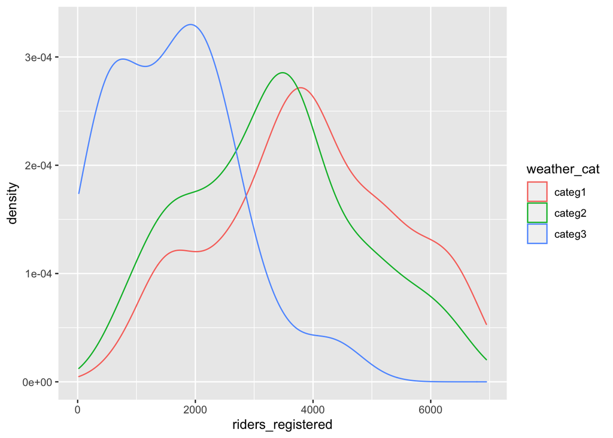

```r
# Construct 2 separate visualizations of the relationship between riders_registered and weather_cat
ggplot(bikes, aes(x = riders_registered, color = weather_cat)) +
  geom_density()
```

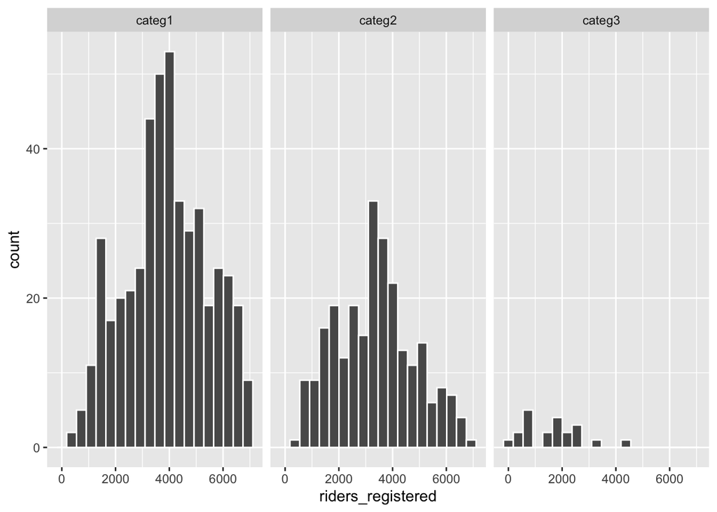

```r
ggplot(bikes, aes(x = riders_registered, color = weather_cat)) +
  geom_histogram(color = "white", bins = 20) +
  facet_wrap(~ weather_cat)
```

```r
# Calculate the mean riders_registered for each of the three weather_cat groups
bikes %>%
  group_by(weather_cat) %>%
  summarise(mean(riders_registered))
```

```
## # A tibble: 3 x 2
##   weather_cat `mean(riders_registered)`
## * <chr>                           <dbl>
## 1 categ1                          3913.
## 2 categ2                          3349.
## 3 categ3                          1618.
```

```r
# Use lm to construct a model of riders_registered vs weather_cat
# Save this as bike_model_4
bike_model_4 <- lm(riders_registered ~ weather_cat, data = bikes)


# Get a short summary of this model
summary(bike_model_4)$coefficients
```

```
##                     Estimate Std. Error   t value      Pr(>|t|)
## (Intercept)        3912.7559   69.66827 56.162665 8.041096e-267
## weather_catcateg2  -564.2458  118.11791 -4.776971  2.152677e-06
## weather_catcateg3 -2294.9464  334.46300 -6.861585  1.457558e-11
```

### Exercise 10: Interpreting the results: Part I

1. Summarize your observations from the visualizations.

There are less and less points for more extreme weathers. Cat 1 and 2 weather are more similar than cat 3.

2. Write out a formula for the model trend.

$$\texttt{riders_registered} = 3912.76 - 564.2458~\texttt{cat2} - 2294.95~ \texttt{cat3}$$

3. Which of the three `weather_cat` categories is the **reference level**? HINT: Which category is first alphabetically and does not show up in the model formula?

$$\texttt{cat1}$$

### Exercise 11: Interpreting the results: Part II

In a newspaper-appropriate way, interpret each of the 3 coefficients in the model. To do so, take note that: - `weather_catcateg2` is 1 for days with category 2 weather & 0 otherwise  
On category 2 days, we often lose about 600 riders. - `weather_catcateg3` is 1 for days with category 3 weather & 0 otherwise  
On category 3 days, we often lose about 2300 riders.

With this in mind, before interpreting the coefficients, it might help to use the model to predict…

- `riders_registered` for days with category 1 weather;
  $$3912$$
- `riders_registered` for days with category 2 weather; and
  $$3348$$
- `riders_registered` for days with category 3 weather.
  $$1618$$

### Exercise 12: Clean, knit, and save your work!

$$\mathcal{Done!}$$

## Optional: digging deeper

### Exercise 13: One more time

Visualize and model the relationship between `riders_registered` and `day_of_week`. Use these to identify the day of the week on which we expect the lowest ridership / highest ridership.